# MTH6139 Time Series

Monthly Airline Passenger Numbers

Cameron Colton

Spring term 2025

# The Dataset

> What is the data?
> 1. This dataset contains recorded totals of international airline passengers, from 1949 to 1960.
> 2. This time series in recorded monthly, in thousands.
> 3. This could be useful for various purposes, including predicting demand, viewing historical tourism levels, and analysing cultural change.

This data is visualised below:

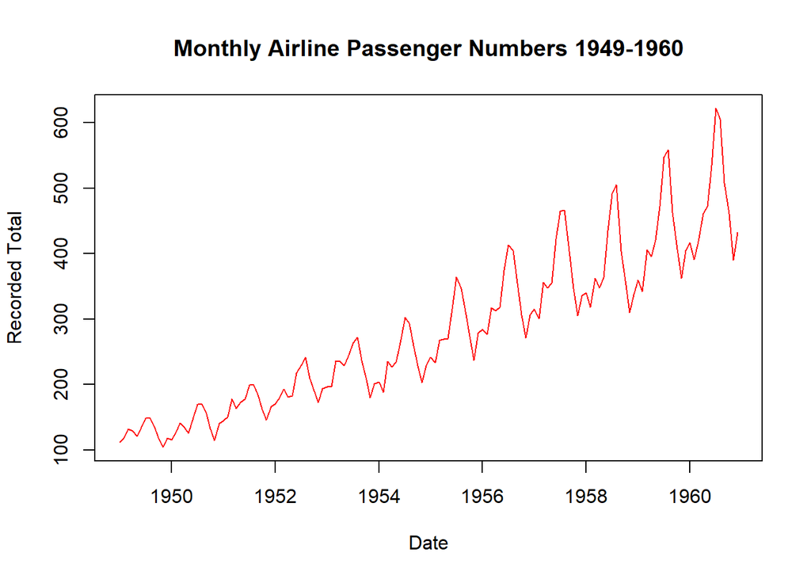

## Time Series to Dataframe conversion

I start by converting the Monthly Airline Passenger Numbers time series into a dataframe. The ‘ds’ column will contain the time (data) and the ‘y’ column will contain the corresponding measurement:

```r
AP.df = data.frame(
    ds=zoo::as.yearmon(time(AirPassengers)),
    y=AirPassengers)
```

This is shown below (note: this is only the start of the data frame for visualisation purposes, the whole is obviously much larger.)

```
##         ds   y
## 1 Jan 1949 112
## 2 Feb 1949 118
## 3 Mar 1949 132
## 4 Apr 1949 129
## 5 May 1949 121
## 6 Jun 1949 135
```

## Linear Regression

I now fit a simple linear regression model to the data to see how well a straight line fits the trend:

```r
model <- lm(y~as.numeric(ds), data = AP.df)
```

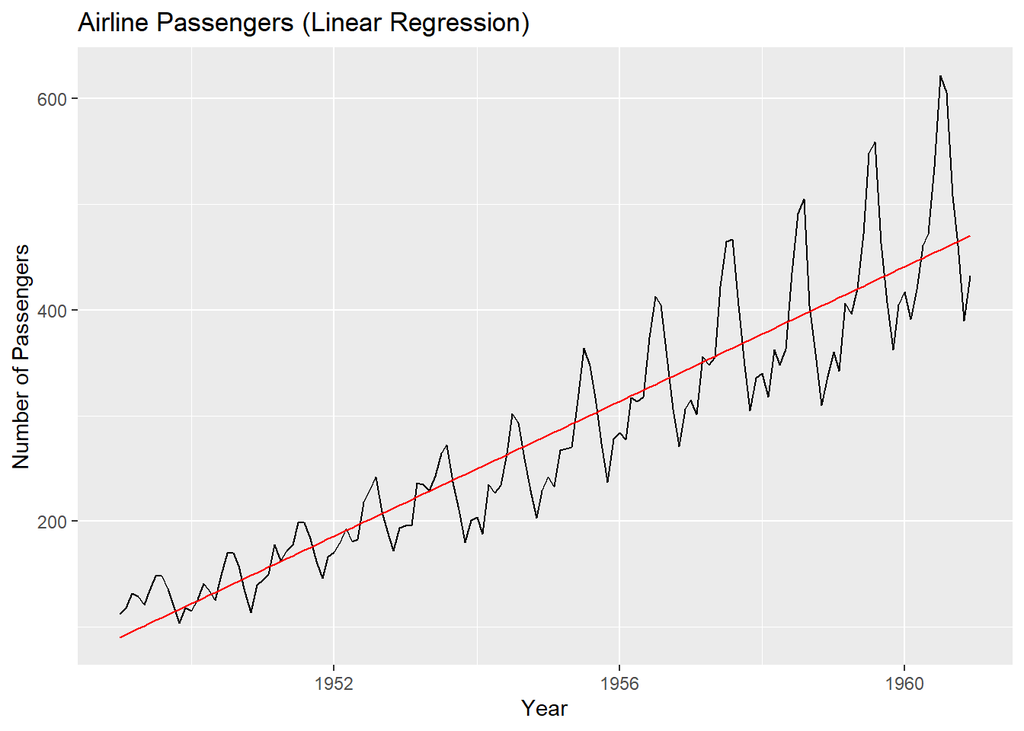

The red line shows a simple linear estimate of the trend, and suggests a consistent increase in rising numbers of passengers. However, it does not take into account the clear seasonality visible in the data.

## Time Series Trend and Seasonality

I look at the decomposition of this time series, to gain a better understanding of it:

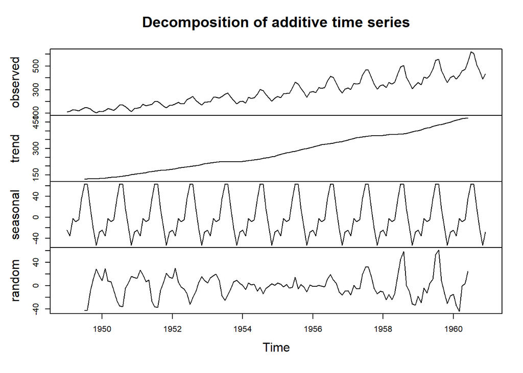

It looks as if there is a steadily rising trend, suggesting that the amount of Airline passengers is rising at a continuous rate. It can also be seen that there is a large seasonal component, most likely yearly in this case (e.g. lots of travel during the summer). The random component seems to suggest that there is still a lot of unexplained variation, not captured by the model (could be explained by external factors such as airline strikes or economic factors). A more sophisticated model like Prophet would likely improve predictions.

## Using ‘Prophet’ to forecast

Next I will use the Prophet package in R to forecast future values of this data frame.

> What is “Prophet” and how does it work?
> 1. Prophet is a tool developed by Meta and used for forecasting.
> 2. It takes into account various levels of trend and seasonality, making it suitable for our data.
> 3. It requires a dataframe with at least 2 columns, in our case ‘ds’ and ‘y’.

```r
m = prophet::prophet(AP.df)
```

```
## [1] "1949-06-01 GMT" "1949-10-01 GMT" "1950-03-01 GMT" "1950-07-01 GMT"
## [5] "1950-12-01 GMT" "1951-04-01 GMT"
```

Above are displayed the first few ‘Changepoints’ of the forecasted model. These are points in time when there is a significant shift in the models trend. For example, there might be a major change in the rate of increase.

I want to create a dataframe that includes both historical data (in model m) and future data (predicted by prophet).We will generate 100 future periods, with quarterly frequency (one data point every 3 months). These dates are generated, and the first few shown, below:

```r
f = prophet::make_future_dataframe(m, periods=100, freq="quarter")
```

```
##           ds
## 1 1949-01-01
## 2 1949-02-01
## 3 1949-03-01
## 4 1949-04-01
## 5 1949-05-01
## 6 1949-06-01
```

## Predicted Plot

I now take this fitted model ‘m’ and dates for future predictions ‘f’ and create a new dataframe. This contains the existing data ‘m’ and future predicted data (for the dates provided in ‘f’) and compiles them into one dataframe:

```r
p = predict(m, f)
```

These observed and predicted values are shown visually in the graph below:

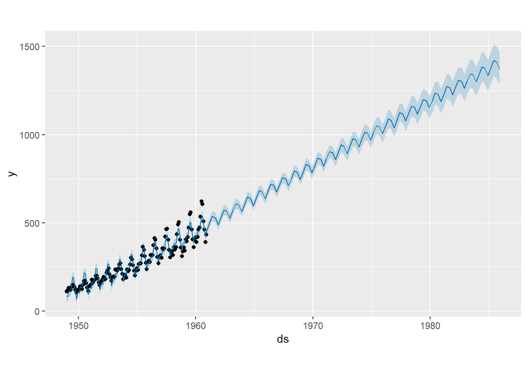

The points on this graph are the original observed values, and the solid line that extends beyond these represents the predicted future values, calculated by the prophet forecaster.The pale blue area shows the uncertainty interval for predicted data (hence this gets larger as time increases). This indicates that the model fits the data used for training quite well, and that the model has understood the main structure of the data. The prophet model has also accounted for seasonality of the data effectively. However, as the uncertainty continues to grow this may mean that any external influence could change the outcome.